# R Notebook

# Relative Elevation Models (REM)

Relative Digital Models (REM) is a digital representation of land surfaces to highlight and exposes its similarities and differences on the elevation of a particular region of interest (ROI). REM are particularly useful in geomorphology, identifying features such as meandes scrolls, foodplain terraces,REM allows a clearly visualization of subtle landforms and floodplains structures.

[Washignton Department of Ecology](https://apps.ecology.wa.gov/publications/documents/1406025.pdf) 2014, proposed a methodology based on REM for Planning Zones and Water Management, by identyfing channel migration zones - areas where a river channel is likely to migrate over time due to erosion, sediment deposition, and other fluvial processes.

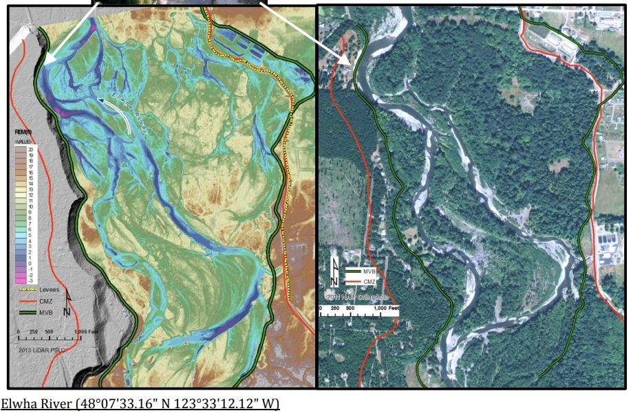

Channel Migration Zones and Modern Valley Bottom mapping. WS Dept of Ecology.

Another interesting use given for REM is highlithed by [Dan Carto](https://dancoecarto.com/creating-rems-in-qgis-the-idw-method) and expose a more artistical driven way to capture the beautiful details.

This notebook aims to foment R communitty/users to explore a development of a REM for a region of interest, merging on concepts of spatial data and manipulation.

The steps of the consists in getting the digital elevation data and a river surface data. Many services and open-sources in R are available to acquire the data and the notebook will explore a few different paths.

## Digital Elevation Model Data (DEM)

DEM is a well-known type of spatial data which represents elevation in a certain space, usually characterized as spatial resolution. The USGS service has a popular DEM raster of 30m spatial resolution. However, Drones and Aerial Imagering by Lidar radar are pushing the data to even high level resolution.

For the region of North America, the USGS provides tiles with spatial resolution of 1 meter. The [USGS web-service](https://basemap.nationalmap.gov/arcgis/rest/services/USGSTopo/MapServer) map hosted in AWS and powered by ArcGIS is an easy way to visualized USGS Tiles.

There are many interesting DEM datasets that can be explored in R, on this NOTEBOOK I explored a bit more about different sources from DEM datasets, includes nacional and regionals as New Zeland, Brazil and Austria. For the pourpose of the notebook, I decided to use 1 meter resolution data from USGS service.

## Boundary Box (Bbox)

The first step is deciding the region of interest to be analysed. Intrigued by understanding better the subtle landform of wetlands due to its important relation in the water cycle, I found it a interesting wetland zone in the legendary Mississipi River.

```r
##Set boundaries of the bbox
xmin <- -91.680547
ymin <- 31.142385
xmax <- -91.481419
ymax <- 31.286846

## Set CRS
crs = 4326  ##WGS84

### Creating the BBox
bbox <- create_bbox(xmin, xmax, ymin, ymax, crs)

## Visualizing the bbox
mapview::mapview(bbox,alpha=0.1,map.types ='Esri.WorldImagery')
```

[output not shown]